# Projeto Python

## Curso PROCESSAMENTO BÁSICO PARA DADOS DE ENSEMBLE HINDCAST

Prof.: Iury Tercio Simoes Sousa

### Gustavo Souza Correia

gustavosouza55@hotmail.com

## Pré-procesamento

Aqui serão importadas as principais bibliotecas a serem utilizadas ao longo do projeto, bem como feito a seleção das séries temporais para as coordenadas das boias de Rio Grande (RS) e Itajaí (SC).

#### NOTA: A rotina calcula em sequência todas as análises para uma boia. Para aplicar as análises para a outra boia, é necessário reiniciar o script e substituir todos "itajai_filtered.csv" por "riogrande_filtered.csv". Sendo assim, neste projeto estarão plotados os resultados para Itajaí (SC).

```python
import numpy as np
import pandas as pd
import manuscript_functions as mf
import matplotlib.pyplot as plt
from math import sqrt
```

### ERA5

Dados de Hs obtidos por simulações feitas com o modelo SWAN sob condições iniciais de vento do ERA5 EDA.

```python
# era5_path = 'C:/Users/gusta/OneDrive/Área de Trabalho/ROAD/hindcast_CSIRO'
# swh_era5_mat_list = ['Hs_jan.mat', 'Hs_feb.mat', 'Hs_mar_apr.mat', 'Hs_mai_ago.mat', 'Hs_sep_dec.mat'] #GSC 19/07/2020
fronteira = 'csiro0'
swh_era5_mat_list = ['Hs_integ_2015_ensmbl_0.mat']   #GSC 19/07/2020
# pnboia_path = '/mnt/c/Users/Mariliasr/OneDrive/Documentos/_UFRGS/Mestrado/Dissert/datasets/ondografos/filtrados'

# Import buoy file
# %cd $pnboia_path

par = 'buoy'
par_index = 53
file = 'itajai_filtered.csv'

swh_df = mf.read_buoy_csv(file, par, par_index)

# Import mat files
# %cd $era5_path

# Definir variáveis
lon = swh_df['lon'][0]
lat = swh_df['lat'][0]
dt_format = 'Hsig_%Y%m%d_%H%M%S'

mat_list = swh_era5_mat_list

swh_era = mf.list2df(mat_list, 'csiro0', lon, lat, dt_format)

swh = swh_df.join(swh_era, how='inner')
```

```python
#era5_path = '/mnt/c/Users/Mariliasr/OneDrive/Documentos/_UFRGS/Mestrado/Dissert/swan/swan_era5_ww3'
#swh_era5_mat_list = ['Hs_era5_ww3_verao.mat', 'Hs_era5_ww3_inv.mat', 'Hs_era5_ww3_pri.mat']
fronteira = 'csiro1'
swh_era5_mat_list = ['Hs_integ_2015_ensmbl_1.mat']

#pnboia_path = '/mnt/c/Users/Mariliasr/OneDrive/Documentos/_UFRGS/Mestrado/Dissert/datasets/ondografos/filtrados'

# Import buoy file
#%cd $pnboia_path

par = 'buoy'
par_index = 53
file = 'itajai_filtered.csv'

swh_df = mf.read_buoy_csv(file, par, par_index)

# Import mat files
#%cd $era5_path

# Definir variáveis
lon = swh_df['lon'][0]
lat = swh_df['lat'][0]
dt_format = 'Hsig_%Y%m%d_%H%M%S'

mat_list = swh_era5_mat_list

swh_era = mf.list2df(mat_list, 'csiro1', lon, lat, dt_format)

swh = swh.join(swh_era, how='inner')
```

```python
fronteira = 'csiro2'
swh_era5_mat_list = ['Hs_integ_2015_ensmbl_2.mat']

#pnboia_path = '/mnt/c/Users/Mariliasr/OneDrive/Documentos/_UFRGS/Mestrado/Dissert/datasets/ondografos/filtrados'

# Import buoy file
#%cd $pnboia_path

par = 'buoy'
par_index = 53
file = 'itajai_filtered.csv'

swh_df = mf.read_buoy_csv(file, par, par_index)

# Import mat files
#%cd $era5_path

# Definir variáveis
lon = swh_df['lon'][0]
lat = swh_df['lat'][0]
dt_format = 'Hsig_%Y%m%d_%H%M%S'

mat_list = swh_era5_mat_list

swh_era = mf.list2df(mat_list, 'csiro2', lon, lat, dt_format)

swh = swh.join(swh_era, how='inner')
```

```python
fronteira = 'csiro3'
swh_era5_mat_list = ['Hs_integ_2015_ensmbl_3.mat']

#pnboia_path = '/mnt/c/Users/Mariliasr/OneDrive/Documentos/_UFRGS/Mestrado/Dissert/datasets/ondografos/filtrados'

# Import buoy file
#%cd $pnboia_path

par = 'buoy'
par_index = 53
file = 'itajai_filtered.csv'

swh_df = mf.read_buoy_csv(file, par, par_index)

# Import mat files
#%cd $era5_path

# Definir variáveis
lon = swh_df['lon'][0]
lat = swh_df['lat'][0]
dt_format = 'Hsig_%Y%m%d_%H%M%S'

mat_list = swh_era5_mat_list

swh_era = mf.list2df(mat_list, 'csiro3', lon, lat, dt_format)

swh = swh.join(swh_era, how='inner')
```

```python
fronteira = 'csiro4'
swh_era5_mat_list = ['Hs_integ_2015_ensmbl_4.mat']

#pnboia_path = '/mnt/c/Users/Mariliasr/OneDrive/Documentos/_UFRGS/Mestrado/Dissert/datasets/ondografos/filtrados'

# Import buoy file
#%cd $pnboia_path

par = 'buoy'
par_index = 53
file = 'itajai_filtered.csv'

swh_df = mf.read_buoy_csv(file, par, par_index)

# Import mat files
#%cd $era5_path

# Definir variáveis
lon = swh_df['lon'][0]
lat = swh_df['lat'][0]
dt_format = 'Hsig_%Y%m%d_%H%M%S'

mat_list = swh_era5_mat_list

swh_era = mf.list2df(mat_list, 'csiro4', lon, lat, dt_format)

swh = swh.join(swh_era, how='inner')
```

```python
fronteira = 'csiro5'
swh_era5_mat_list = ['Hs_integ_2015_ensmbl_5.mat']

#pnboia_path = '/mnt/c/Users/Mariliasr/OneDrive/Documentos/_UFRGS/Mestrado/Dissert/datasets/ondografos/filtrados'

# Import buoy file
#%cd $pnboia_path

par = 'buoy'
par_index = 53
file = 'itajai_filtered.csv'

swh_df = mf.read_buoy_csv(file, par, par_index)

# Import mat files
#%cd $era5_path

# Definir variáveis
lon = swh_df['lon'][0]
lat = swh_df['lat'][0]
dt_format = 'Hsig_%Y%m%d_%H%M%S'

mat_list = swh_era5_mat_list

swh_era = mf.list2df(mat_list, 'csiro5', lon, lat, dt_format)

swh = swh.join(swh_era, how='inner')
```

```python
fronteira = 'csiro6'
swh_era5_mat_list = ['Hs_integ_2015_ensmbl_6.mat']

#pnboia_path = '/mnt/c/Users/Mariliasr/OneDrive/Documentos/_UFRGS/Mestrado/Dissert/datasets/ondografos/filtrados'

# Import buoy file
#%cd $pnboia_path

par = 'buoy'
par_index = 53
file = 'itajai_filtered.csv'

swh_df = mf.read_buoy_csv(file, par, par_index)

# Import mat files
#%cd $era5_path

# Definir variáveis
lon = swh_df['lon'][0]
lat = swh_df['lat'][0]
dt_format = 'Hsig_%Y%m%d_%H%M%S'

mat_list = swh_era5_mat_list

swh_era = mf.list2df(mat_list, 'csiro6', lon, lat, dt_format)

swh = swh.join(swh_era, how='inner')
```

```python
fronteira = 'csiro7'
swh_era5_mat_list = ['Hs_integ_2015_ensmbl_7.mat']

#pnboia_path = '/mnt/c/Users/Mariliasr/OneDrive/Documentos/_UFRGS/Mestrado/Dissert/datasets/ondografos/filtrados'

# Import buoy file
#%cd $pnboia_path

par = 'buoy'
par_index = 53
file = 'itajai_filtered.csv'

swh_df = mf.read_buoy_csv(file, par, par_index)

# Import mat files
#%cd $era5_path

# Definir variáveis
lon = swh_df['lon'][0]
lat = swh_df['lat'][0]
dt_format = 'Hsig_%Y%m%d_%H%M%S'

mat_list = swh_era5_mat_list

swh_era = mf.list2df(mat_list, 'csiro7', lon, lat, dt_format)

swh = swh.join(swh_era, how='inner')
```

```python
fronteira = 'csiro8'
swh_era5_mat_list = ['Hs_integ_2015_ensmbl_8.mat']

#pnboia_path = '/mnt/c/Users/Mariliasr/OneDrive/Documentos/_UFRGS/Mestrado/Dissert/datasets/ondografos/filtrados'

# Import buoy file
#%cd $pnboia_path

par = 'buoy'
par_index = 53
file = 'itajai_filtered.csv'

swh_df = mf.read_buoy_csv(file, par, par_index)

# Import mat files
#%cd $era5_path

# Definir variáveis
lon = swh_df['lon'][0]
lat = swh_df['lat'][0]
dt_format = 'Hsig_%Y%m%d_%H%M%S'

mat_list = swh_era5_mat_list

swh_era = mf.list2df(mat_list, 'csiro8', lon, lat, dt_format)

swh = swh.join(swh_era, how='inner')
```

```python
fronteira = 'csiro9'
swh_era5_mat_list = ['Hs_integ_2015_ensmbl_9.mat']

#pnboia_path = '/mnt/c/Users/Mariliasr/OneDrive/Documentos/_UFRGS/Mestrado/Dissert/datasets/ondografos/filtrados'

# Import buoy file
#%cd $pnboia_path

par = 'buoy'
par_index = 53
file = 'itajai_filtered.csv'

swh_df = mf.read_buoy_csv(file, par, par_index)

# Import mat files
#%cd $era5_path

# Definir variáveis
lon = swh_df['lon'][0]
lat = swh_df['lat'][0]
dt_format = 'Hsig_%Y%m%d_%H%M%S'

mat_list = swh_era5_mat_list

swh_era = mf.list2df(mat_list, 'csiro9', lon, lat, dt_format)

swh = swh.join(swh_era, how='inner')
```

Simulação determinística (ou controle), realizada sob ventos de reanálise convencional.

```python
fronteira = 'csiro_DTMRun'
swh_era5_mat_list = ['Hs_integ_2015_DTM.mat']

#pnboia_path = '/mnt/c/Users/Mariliasr/OneDrive/Documentos/_UFRGS/Mestrado/Dissert/datasets/ondografos/filtrados'

# Import buoy file
#%cd $pnboia_path

par = 'buoy'
par_index = 53
file = 'itajai_filtered.csv'

swh_df = mf.read_buoy_csv(file, par, par_index)

# Import mat files
#%cd $era5_path

# Definir variáveis
lon = swh_df['lon'][0]
lat = swh_df['lat'][0]
dt_format = 'Hsig_%Y%m%d_%H%M%S'

mat_list = swh_era5_mat_list

swh_era = mf.list2df(mat_list, 'csiro_DTMRun', lon, lat, dt_format)

swh = swh.join(swh_era, how='inner')
```

### WRF

Dados de Hs obtidos por simulações feitas com o modelo SWAN sob condições iniciais de vento do ERA5 EDA após refinamento dinâmico pelo modelo atmosférico WRF.

```python
fronteira = 'csiro_WRF00'
swh_era5_mat_list = ['Hs_integ_WRF_ensmbl_0.mat']

#pnboia_path = '/mnt/c/Users/Mariliasr/OneDrive/Documentos/_UFRGS/Mestrado/Dissert/datasets/ondografos/filtrados'

# Import buoy file
#%cd $pnboia_path

par = 'buoy'
par_index = 53
file = 'itajai_filtered.csv'

swh_df = mf.read_buoy_csv(file, par, par_index)

# Import mat files
#%cd $era5_path

# Definir variáveis
lon = swh_df['lon'][0]
lat = swh_df['lat'][0]
dt_format = 'Hsig_%Y%m%d_%H%M%S'

mat_list = swh_era5_mat_list

swh_era = mf.list2df(mat_list, 'csiro_WRF00', lon, lat, dt_format)

swh = swh.join(swh_era, how='inner')
```

```python
fronteira = 'csiro_WRF01'
swh_era5_mat_list = ['Hs_integ_WRF_ensmbl_1.mat']

#pnboia_path = '/mnt/c/Users/Mariliasr/OneDrive/Documentos/_UFRGS/Mestrado/Dissert/datasets/ondografos/filtrados'

# Import buoy file
#%cd $pnboia_path

par = 'buoy'
par_index = 53
file = 'itajai_filtered.csv'

swh_df = mf.read_buoy_csv(file, par, par_index)

# Import mat files
#%cd $era5_path

# Definir variáveis
lon = swh_df['lon'][0]
lat = swh_df['lat'][0]
dt_format = 'Hsig_%Y%m%d_%H%M%S'

mat_list = swh_era5_mat_list

swh_era = mf.list2df(mat_list, 'csiro_WRF01', lon, lat, dt_format)

swh = swh.join(swh_era, how='inner')
```

```python
fronteira = 'csiro_WRF02'
swh_era5_mat_list = ['Hs_integ_WRF_ensmbl_2.mat']

#pnboia_path = '/mnt/c/Users/Mariliasr/OneDrive/Documentos/_UFRGS/Mestrado/Dissert/datasets/ondografos/filtrados'

# Import buoy file
#%cd $pnboia_path

par = 'buoy'
par_index = 53
file = 'itajai_filtered.csv'

swh_df = mf.read_buoy_csv(file, par, par_index)

# Import mat files
#%cd $era5_path

# Definir variáveis
lon = swh_df['lon'][0]
lat = swh_df['lat'][0]
dt_format = 'Hsig_%Y%m%d_%H%M%S'

mat_list = swh_era5_mat_list

swh_era = mf.list2df(mat_list, 'csiro_WRF02', lon, lat, dt_format)

swh = swh.join(swh_era, how='inner')
```

```python
fronteira = 'csiro_WRF03'
swh_era5_mat_list = ['Hs_integ_WRF_ensmbl_3.mat']

#pnboia_path = '/mnt/c/Users/Mariliasr/OneDrive/Documentos/_UFRGS/Mestrado/Dissert/datasets/ondografos/filtrados'

# Import buoy file
#%cd $pnboia_path

par = 'buoy'
par_index = 53
file = 'itajai_filtered.csv'

swh_df = mf.read_buoy_csv(file, par, par_index)

# Import mat files
#%cd $era5_path

# Definir variáveis
lon = swh_df['lon'][0]
lat = swh_df['lat'][0]
dt_format = 'Hsig_%Y%m%d_%H%M%S'

mat_list = swh_era5_mat_list

swh_era = mf.list2df(mat_list, 'csiro_WRF03', lon, lat, dt_format)

swh = swh.join(swh_era, how='inner')
```

```python
fronteira = 'csiro_WRF04'
swh_era5_mat_list = ['Hs_integ_WRF_ensmbl_4.mat']

#pnboia_path = '/mnt/c/Users/Mariliasr/OneDrive/Documentos/_UFRGS/Mestrado/Dissert/datasets/ondografos/filtrados'

# Import buoy file
#%cd $pnboia_path

par = 'buoy'
par_index = 53
file = 'itajai_filtered.csv'

swh_df = mf.read_buoy_csv(file, par, par_index)

# Import mat files
#%cd $era5_path

# Definir variáveis
lon = swh_df['lon'][0]
lat = swh_df['lat'][0]
dt_format = 'Hsig_%Y%m%d_%H%M%S'

mat_list = swh_era5_mat_list

swh_era = mf.list2df(mat_list, 'csiro_WRF04', lon, lat, dt_format)

swh = swh.join(swh_era, how='inner')
```

```python
fronteira = 'csiro_WRF05'
swh_era5_mat_list = ['Hs_integ_WRF_ensmbl_5.mat']

#pnboia_path = '/mnt/c/Users/Mariliasr/OneDrive/Documentos/_UFRGS/Mestrado/Dissert/datasets/ondografos/filtrados'

# Import buoy file
#%cd $pnboia_path

par = 'buoy'
par_index = 53
file = 'itajai_filtered.csv'

swh_df = mf.read_buoy_csv(file, par, par_index)

# Import mat files
#%cd $era5_path

# Definir variáveis
lon = swh_df['lon'][0]
lat = swh_df['lat'][0]
dt_format = 'Hsig_%Y%m%d_%H%M%S'

mat_list = swh_era5_mat_list

swh_era = mf.list2df(mat_list, 'csiro_WRF05', lon, lat, dt_format)

swh = swh.join(swh_era, how='inner')
```

```python
fronteira = 'csiro_WRF06'
swh_era5_mat_list = ['Hs_integ_WRF_ensmbl_6.mat']

#pnboia_path = '/mnt/c/Users/Mariliasr/OneDrive/Documentos/_UFRGS/Mestrado/Dissert/datasets/ondografos/filtrados'

# Import buoy file
#%cd $pnboia_path

par = 'buoy'
par_index = 53
file = 'itajai_filtered.csv'

swh_df = mf.read_buoy_csv(file, par, par_index)

# Import mat files
#%cd $era5_path

# Definir variáveis
lon = swh_df['lon'][0]
lat = swh_df['lat'][0]
dt_format = 'Hsig_%Y%m%d_%H%M%S'

mat_list = swh_era5_mat_list

swh_era = mf.list2df(mat_list, 'csiro_WRF06', lon, lat, dt_format)

swh = swh.join(swh_era, how='inner')
```

```python
fronteira = 'csiro_WRF07'
swh_era5_mat_list = ['Hs_integ_WRF_ensmbl_7.mat']

#pnboia_path = '/mnt/c/Users/Mariliasr/OneDrive/Documentos/_UFRGS/Mestrado/Dissert/datasets/ondografos/filtrados'

# Import buoy file
#%cd $pnboia_path

par = 'buoy'
par_index = 53
file = 'itajai_filtered.csv'

swh_df = mf.read_buoy_csv(file, par, par_index)

# Import mat files
#%cd $era5_path

# Definir variáveis
lon = swh_df['lon'][0]
lat = swh_df['lat'][0]
dt_format = 'Hsig_%Y%m%d_%H%M%S'

mat_list = swh_era5_mat_list

swh_era = mf.list2df(mat_list, 'csiro_WRF07', lon, lat, dt_format)

swh = swh.join(swh_era, how='inner')
```

```python
fronteira = 'csiro_WRF08'
swh_era5_mat_list = ['Hs_integ_WRF_ensmbl_8.mat']

#pnboia_path = '/mnt/c/Users/Mariliasr/OneDrive/Documentos/_UFRGS/Mestrado/Dissert/datasets/ondografos/filtrados'

# Import buoy file
#%cd $pnboia_path

par = 'buoy'
par_index = 53
file = 'itajai_filtered.csv'

swh_df = mf.read_buoy_csv(file, par, par_index)

# Import mat files
#%cd $era5_path

# Definir variáveis
lon = swh_df['lon'][0]
lat = swh_df['lat'][0]
dt_format = 'Hsig_%Y%m%d_%H%M%S'

mat_list = swh_era5_mat_list

swh_era = mf.list2df(mat_list, 'csiro_WRF08', lon, lat, dt_format)

swh = swh.join(swh_era, how='inner')
```

```python
fronteira = 'csiro_WRF09'
swh_era5_mat_list = ['Hs_integ_WRF_ensmbl_9.mat']

#pnboia_path = '/mnt/c/Users/Mariliasr/OneDrive/Documentos/_UFRGS/Mestrado/Dissert/datasets/ondografos/filtrados'

# Import buoy file
#%cd $pnboia_path

par = 'buoy'
par_index = 53
file = 'itajai_filtered.csv'

swh_df = mf.read_buoy_csv(file, par, par_index)

# Import mat files
#%cd $era5_path

# Definir variáveis
lon = swh_df['lon'][0]
lat = swh_df['lat'][0]
dt_format = 'Hsig_%Y%m%d_%H%M%S'

mat_list = swh_era5_mat_list

swh_era = mf.list2df(mat_list, 'csiro_WRF09', lon, lat, dt_format)

swh = swh.join(swh_era, how='inner')
```

# Ensemble Mean & Spread

Calcula o ENS Mean e Spread dos dois conjuntos de dados (i.e., ERA5 e WRF).

## ERA5

```python
# Selecicona os dados do experimento "csiro" (ou seja, 10 membros do Era5) e calcula o ENS Mean.

swh2 = swh[['csiro0', 'csiro1','csiro2','csiro3','csiro4','csiro5','csiro6','csiro7','csiro8','csiro9']]

ensmean = (swh2.csiro0 + swh2.csiro1 + swh2.csiro2 + swh2.csiro3 + swh2.csiro4 + swh2.csiro5 + swh2.csiro6 + swh2.csiro7 + swh2.csiro8 + swh2.csiro9) / 10
#plt.plot(ensmean)
```

```python
###### O Cálculo utilizado para o ENS Spread é o mesmo conhecido como Desvio Padrão (STD)
###### Aqui ele foi calculado por etapa, pois não fui muito a fundo para criar um Loop.

#standard_deviation = sqrt( sum( (x - mean)^2 ) / count(x))
csiro0_etp1 = (swh2.csiro0 - ensmean)**2 / 10 #swh2.csiro0.count()
csiro1_etp1 = (swh2.csiro1 - ensmean)**2 / 10 #swh2.csiro1.count()
csiro2_etp1 = (swh2.csiro2 - ensmean)**2 / 10 #swh2.csiro2.count()
csiro3_etp1 = (swh2.csiro3 - ensmean)**2 / 10 #swh2.csiro3.count()
csiro4_etp1 = (swh2.csiro4 - ensmean)**2 / 10 #swh2.csiro4.count()
csiro5_etp1 = (swh2.csiro5 - ensmean)**2 / 10 #swh2.csiro5.count()
csiro6_etp1 = (swh2.csiro6 - ensmean)**2 / 10 #swh2.csiro6.count()
csiro7_etp1 = (swh2.csiro7 - ensmean)**2 / 10 #swh2.csiro7.count()
csiro8_etp1 = (swh2.csiro8 - ensmean)**2 / 10 #swh2.csiro8.count()
csiro9_etp1 = (swh2.csiro9 - ensmean)**2 / 10 #swh2.csiro9.count()

#standard_deviation = sqrt( sum( (x - mean)^2 ) / count(x))
csiro_sum_etp2 = csiro0_etp1 + csiro1_etp1 + csiro2_etp1 + csiro3_etp1 + csiro4_etp1 + csiro5_etp1 + csiro6_etp1 + csiro7_etp1 + csiro8_etp1 + csiro9_etp1
csiro_sum_etp2

#standard_deviation = sqrt( sum( (x - mean)^2 ) / count(x))
ensspd = csiro_sum_etp2.apply(sqrt)
ensspd

# plt.plot(ensspd)

ensspd_positivo = ensmean + ensspd
ensspd_negativo = ensmean - ensspd
```

## WRF

```python
# Selecicona os dados do experimento "csiro_WRF" (ou seja, 10 membros do WRF) e calcula o ENS Mean.

swh2_wrf = swh[['csiro_WRF00', 'csiro_WRF01','csiro_WRF02','csiro_WRF03','csiro_WRF04','csiro_WRF05','csiro_WRF06','csiro_WRF07','csiro_WRF08','csiro_WRF09']]

ensmean_wrf = (swh2_wrf.csiro_WRF00 + swh2_wrf.csiro_WRF01 + swh2_wrf.csiro_WRF02 + swh2_wrf.csiro_WRF03 + swh2_wrf.csiro_WRF04 + swh2_wrf.csiro_WRF05 + swh2_wrf.csiro_WRF06 + swh2_wrf.csiro_WRF07 + swh2_wrf.csiro_WRF08 + swh2_wrf.csiro_WRF09) / 10
```

```python
#standard_deviation = sqrt( sum( (x - mean)^2 ) / count(x))
csiro_WRF00_etp1 = (swh2_wrf.csiro_WRF00 - ensmean_wrf)**2 / 10 #swh2_wrf.csiro_WRF00.count()
csiro_WRF01_etp1 = (swh2_wrf.csiro_WRF01 - ensmean_wrf)**2 / 10 #swh2_wrf.csiro_WRF01.count()
csiro_WRF02_etp1 = (swh2_wrf.csiro_WRF02 - ensmean_wrf)**2 / 10 #swh2_wrf.csiro_WRF02.count()
csiro_WRF03_etp1 = (swh2_wrf.csiro_WRF03 - ensmean_wrf)**2 / 10 #swh2_wrf.csiro_WRF03.count()
csiro_WRF04_etp1 = (swh2_wrf.csiro_WRF04 - ensmean_wrf)**2 / 10 #swh2_wrf.csiro_WRF04.count()
csiro_WRF05_etp1 = (swh2_wrf.csiro_WRF05 - ensmean_wrf)**2 / 10 #swh2_wrf.csiro_WRF05.count()
csiro_WRF06_etp1 = (swh2_wrf.csiro_WRF06 - ensmean_wrf)**2 / 10 #swh2_wrf.csiro_WRF06.count()
csiro_WRF07_etp1 = (swh2_wrf.csiro_WRF07 - ensmean_wrf)**2 / 10 #swh2_wrf.csiro_WRF07.count()
csiro_WRF08_etp1 = (swh2_wrf.csiro_WRF08 - ensmean_wrf)**2 / 10 #swh2_wrf.csiro_WRF08.count()
csiro_WRF09_etp1 = (swh2_wrf.csiro_WRF09 - ensmean_wrf)**2 / 10 #swh2_wrf.csiro_WRF09.count()

#standard_deviation = sqrt( sum( (x - mean)^2 ) / count(x))
csiro_wrf_sum_etp2 = csiro_WRF00_etp1 + csiro_WRF01_etp1 + csiro_WRF02_etp1 + csiro_WRF03_etp1 + csiro_WRF04_etp1 + csiro_WRF05_etp1 + csiro_WRF06_etp1 + csiro_WRF07_etp1 + csiro_WRF08_etp1 + csiro_WRF09_etp1
csiro_wrf_sum_etp2

#standard_deviation = sqrt( sum( (x - mean)^2 ) / count(x))
ensspd_wrf = csiro_wrf_sum_etp2.apply(sqrt)

# plt.plot(ensspd_wrf)

ensspd_wrf_positivo = ensmean_wrf + ensspd_wrf
ensspd_wrf_negativo = ensmean_wrf - ensspd_wrf
```

## Plots

### Serão exibidos os resultados referentes a localidade de Itajaí (SC)

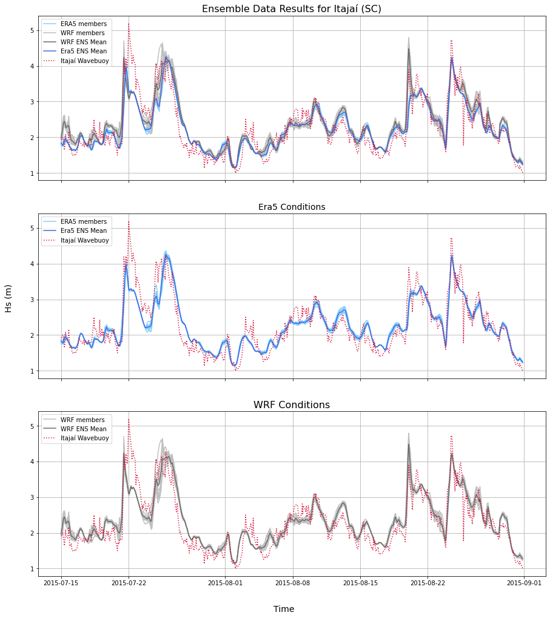

```python
############# PLOT FINAL ENSEMBLE RESULTS ###################
############################################################

fig, axs = plt.subplots(3, figsize=(15,17), sharex=True, sharey=True)
#fig.suptitle('Ensemble Data Results for Itajaí (SC)')
axs[0].set_title('Ensemble Data Results for Itajaí (SC)', fontsize = 16)
axs[0].plot(swh['csiro0'], color = 'lightskyblue', label = 'ERA5 members') #4344 defalt para um ano
axs[0].plot(swh['csiro1'], color = 'lightskyblue')
axs[0].plot(swh['csiro2'], color = 'lightskyblue')
axs[0].plot(swh['csiro3'], color = 'lightskyblue')
axs[0].plot(swh['csiro4'], color = 'lightskyblue')
axs[0].plot(swh['csiro5'], color = 'lightskyblue')
axs[0].plot(swh['csiro6'], color = 'lightskyblue')
axs[0].plot(swh['csiro7'], color = 'lightskyblue')
axs[0].plot(swh['csiro8'], color = 'lightskyblue')
axs[0].plot(swh['csiro9'], color = 'lightskyblue')
axs[0].plot(swh['csiro_WRF00'], color = 'silver', label = 'WRF members') #4344 defalt para um ano
axs[0].plot(swh['csiro_WRF01'], color = 'silver')
axs[0].plot(swh['csiro_WRF02'], color = 'silver')
axs[0].plot(swh['csiro_WRF03'], color = 'silver')
axs[0].plot(swh['csiro_WRF04'], color = 'silver')
axs[0].plot(swh['csiro_WRF05'], color = 'silver')
axs[0].plot(swh['csiro_WRF06'], color = 'silver')
axs[0].plot(swh['csiro_WRF07'], color = 'silver')
axs[0].plot(swh['csiro_WRF08'], color = 'silver')
axs[0].plot(swh['csiro_WRF09'], color = 'silver')
axs[0].plot(ensmean_wrf, color = 'dimgray', label = 'WRF ENS Mean')
axs[0].plot(ensmean, color = 'royalblue', label = 'Era5 ENS Mean')
#axs[0].plot(swh['csiro_DTMRun'], 'k--', color = 'maroon', label = 'DTM ERA5')
axs[0].plot(swh['buoy'], 'k:', color = 'crimson', label = 'Itajaí Wavebuoy')
axs[0].grid(True)
axs[0].legend(loc='upper left')

axs[1].set_title('Era5 Conditions', fontsize = 14)
axs[1].plot(swh['csiro0'], color = 'lightskyblue', label = 'ERA5 members') #4344 defalt para um ano
axs[1].plot(swh['csiro1'], color = 'lightskyblue')
axs[1].plot(swh['csiro2'], color = 'lightskyblue')
axs[1].plot(swh['csiro3'], color = 'lightskyblue')
axs[1].plot(swh['csiro4'], color = 'lightskyblue')
axs[1].plot(swh['csiro5'], color = 'lightskyblue')
axs[1].plot(swh['csiro6'], color = 'lightskyblue')
axs[1].plot(swh['csiro7'], color = 'lightskyblue')
axs[1].plot(swh['csiro8'], color = 'lightskyblue')
axs[1].plot(swh['csiro9'], color = 'lightskyblue')
axs[1].plot(ensmean, color = 'royalblue', label = 'Era5 ENS Mean')
#axs[1].plot(swh['csiro_DTMRun'], 'k--', color = 'maroon', label = 'DTM ERA5')
axs[1].plot(swh['buoy'], 'k:', color = 'crimson', label = 'Itajaí Wavebuoy')
axs[1].grid(True)
axs[1].legend(loc='upper left')

axs[2].set_title('WRF Conditions', fontsize = 16)
axs[2].plot(swh['csiro_WRF00'], color = 'silver', label = 'WRF members') #4344 defalt para um ano
axs[2].plot(swh['csiro_WRF01'], color = 'silver')
axs[2].plot(swh['csiro_WRF02'], color = 'silver')
axs[2].plot(swh['csiro_WRF03'], color = 'silver')
axs[2].plot(swh['csiro_WRF04'], color = 'silver')
axs[2].plot(swh['csiro_WRF05'], color = 'silver')
axs[2].plot(swh['csiro_WRF06'], color = 'silver')
axs[2].plot(swh['csiro_WRF07'], color = 'silver')
axs[2].plot(swh['csiro_WRF08'], color = 'silver')
axs[2].plot(swh['csiro_WRF09'], color = 'silver')
axs[2].plot(ensmean_wrf, color = 'dimgray', label = 'WRF ENS Mean')
#axs[2].plot(swh['csiro_DTMRun'], 'k--', color = 'maroon', label = 'DTM ERA5')
axs[2].plot(swh['buoy'], 'k:', color = 'crimson', label = 'Itajaí Wavebuoy')
axs[2].grid(True)
axs[2].legend(loc='upper left')

fig.text(0.5, 0.08, 'Time', ha='center', va='center', fontsize = 14)
fig.text(0.08, 0.5, 'Hs (m)', ha='center', va='center', rotation='vertical', fontsize = 14)
#fig.savefig('ensembleMEAN_ERA5xWRFxBoia_RG_FINAL.png', format='png', dpi = 300)
```

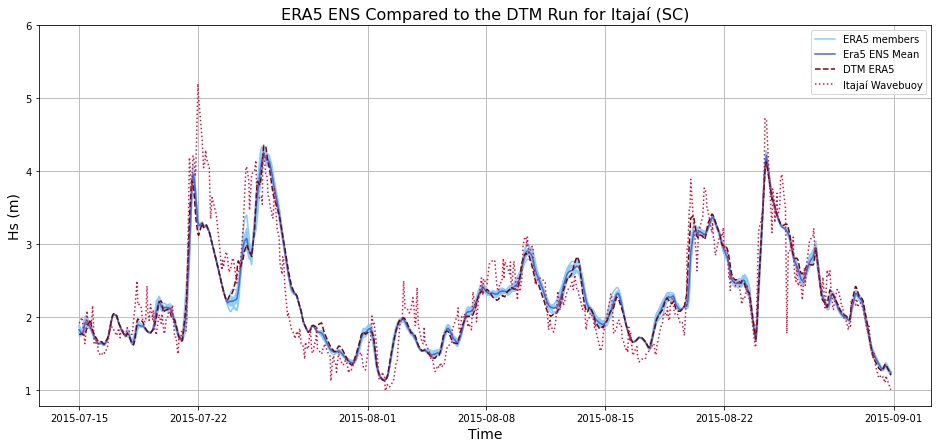

```python
####### PLOT ERA5 X DTM RUN ###########
######################################
values = [1, 2, 3, 4, 5, 6]
plt.figure(figsize=(16,7))
#fig.suptitle('Ensemble Data Results for Itajaí (SC)')
plt.title('ERA5 ENS Compared to the DTM Run for Itajaí (SC)', fontsize = 16)

#axs.set_title('Era5 Conditions', fontsize = 14)
plt.plot(swh['csiro0'], color = 'lightskyblue', label = 'ERA5 members') #4344 defalt para um ano
plt.plot(swh['csiro1'], color = 'lightskyblue')
plt.plot(swh['csiro2'], color = 'lightskyblue')
plt.plot(swh['csiro3'], color = 'lightskyblue')
plt.plot(swh['csiro4'], color = 'lightskyblue')
plt.plot(swh['csiro5'], color = 'lightskyblue')
plt.plot(swh['csiro6'], color = 'lightskyblue')
plt.plot(swh['csiro7'], color = 'lightskyblue')
plt.plot(swh['csiro8'], color = 'lightskyblue')
plt.plot(swh['csiro9'], color = 'lightskyblue')
plt.plot(ensmean, color = 'royalblue', label = 'Era5 ENS Mean')
plt.plot(swh['csiro_DTMRun'], 'k--', color = 'maroon', label = 'DTM ERA5')
plt.plot(swh['buoy'], 'k:', color = 'crimson', label = 'Itajaí Wavebuoy')
plt.yticks(values)
plt.xlabel('Time', fontsize = 14)
plt.ylabel('Hs (m)', fontsize = 14)
plt.legend()
plt.grid(True)
#plt.savefig('ensembleERA5xDTM_itajai_FINAL.png', format='png', dpi = 300)
```

#### OBS.: Foi calculado o spread positivo e negativo dos experimentos, na intenção de plotar um gráfico com a função "fill_between" do ERA5 e do WRF, mas dá erro por um problema com o panda series, o qual não reconhece os tempos na hora de plotar com esta função em específico.

Exemplo de como seria:

```python
plt.plot(ensspd_wrf_positivo, '-', color = 'tab:gray', alpha = 0.4)
plt.plot(ensmean_wrf, '--', color = 'k')
plt.plot(ensspd_wrf_negativo, '-', color = 'tab:gray', alpha = 0.4)
plt.fill_between(np.arange(len(ensmean_wrf)), ensspd_wrf_positivo, ensspd_wrf_negativo, color = 'tab:gray', alpha = 0.4)
plt.gcf().set_size_inches(15,7)
```